# Eurostat: First Decisions on Afghanistan (2017)

ynux

August, 2018

### Focus Afghanistan, with Eurostat Data

Let’s have a look at first decisions on asylum requests from Afghan citizens, in Europe.

This means that we use the dataset `migr_asydcfsta`: “First instance decisions on applications by citizenship, age and sex Annual aggregated data (rounded)”. (Remark: For Germany, these are the the BAMF decisions. Don’t confuse this with the “first instance” in the legal system of Germany, that would be the Verwaltungsgericht.) (Second Remark: There’s also quarterly data, we can work with this later.)

This data covers the years from 2008 to 2017 (as of August 2018). It’s quite big - 85 MB, and 13’311’070 values. Loading this takes some minutes on my pretty strong laptop. We start with a reduced data set that was pulled and saved with the following code:

```
library(eurostat)
migr_asydcfsta=get_eurostat("migr_asydcfsta")
saveRDS(migr_asydcfsta, file="/tmp/migr_asydcfsta_20180812.rds")
```

The data covers 32 European countries (`geo`). Some don’t have enough data to do useful analysis. Let’s ignore them.

Let’s have a quick look at what we have.

```r
# The first few rows:
glimpse(migr_asydcfsta)
```

```
## Observations: 13,311,070
## Variables: 8
## $ unit     <fctr> PER, PER, PER, PER, PER, PER, PER, PER, PER, PER, PE...
## $ citizen  <fctr> AD, AD, AD, AD, AD, AD, AD, AD, AD, AD, AD, AD, AD, ...
## $ sex      <fctr> F, F, F, F, F, F, F, F, F, F, F, F, F, F, F, F, F, F...
## $ age      <fctr> TOTAL, TOTAL, TOTAL, TOTAL, TOTAL, TOTAL, TOTAL, TOT...
## $ decision <fctr> GENCONV, GENCONV, GENCONV, GENCONV, GENCONV, GENCONV...
## $ geo      <fctr> AT, BE, BG, CH, CY, CZ, DE, DK, EE, EL, ES, EU28, FI...
## $ time     <date> 2017-01-01, 2017-01-01, 2017-01-01, 2017-01-01, 2017...
## $ values   <dbl> 0, 0, 0, 0, 0, 0, 0, 0, 0, 0, 0, 0, 0, 0, 0, 0, 0, 0,...
```

```r
# A look at the structure of our data, also showing the categories (sex, age, decisions):
str(migr_asydcfsta)
```

```
## Classes 'tbl_df', 'tbl' and 'data.frame':    13311070 obs. of  8 variables:
##  $ unit    : Factor w/ 1 level "PER": 1 1 1 1 1 1 1 1 1 1 ...
##  $ citizen : Factor w/ 207 levels "AD","AE","AF",..: 1 1 1 1 1 1 1 1 1 1 ...
##  $ sex     : Factor w/ 4 levels "F","M","T","UNK": 1 1 1 1 1 1 1 1 1 1 ...
##  $ age     : Factor w/ 8 levels "TOTAL","UNK",..: 1 1 1 1 1 1 1 1 1 1 ...
##  $ decision: Factor w/ 7 levels "GENCONV","HUMSTAT",..: 1 1 1 1 1 1 1 1 1 1 ...
##  $ geo     : Factor w/ 34 levels "AT","BE","BG",..: 1 2 3 4 5 6 7 8 9 10 ...
##  $ time    : Date, format: "2017-01-01" "2017-01-01" ...
##  $ values  : num  0 0 0 0 0 0 0 0 0 0 ...
```

The important stuff is: * geo: The EU country * citizen: The applicant’s citizenship, in our case, Afghanistan * decision: The first decision on the application * time: in our case, 2017

This is too much information. Let’s reduce it:

```r
cutoff=1000
major_geo_total=filter(migr_asydcfsta, values > cutoff, time == "2017-01-01", decision == "TOTAL", sex == "T", age == "TOTAL", citizen == "AF", geo != "EU28", geo != "TOTAL") %>%
  select(geo,values) %>%
  arrange(desc(values))
```

### A first look into the data

```r
major_geo_total
```

```
## # A tibble: 15 x 2
##       geo values
##    <fctr>  <dbl>
##  1     DE 109732
##  2     SE  25155
##  3     AT  17730
##  4     FR   7516
##  5     BE   5160
##  6     CH   3094
##  7     EL   2134
##  8     IT   1972
##  9     UK   1909
## 10     NL   1894
## 11     HU   1800
## 12     NO   1518
## 13     BG   1388
## 14     DK   1349
## 15     FI   1334
```

### Reducing to the relevant deciding countries

OK, this is what we’ll be working with.

Looking at the number of decisions per country brought the first surprise for me. In 2017, there were 15 countries with more than 1000 decisions on asylum application from Afghan citizens. All other 17 countries account for only 580 decisions.

In total there were 184’265 decisions on Afghanistan in 2017.

```r
other_geo_total=filter(migr_asydcfsta, values <= cutoff, time == "2017-01-01", decision == "TOTAL", sex == "T", age == "TOTAL", citizen == "AF", geo != "EU28", geo != "TOTAL") %>% select(values)
dec_others_total <- sum(other_geo_total$values)
dec_others_total
```

```
## [1] 580
```

If you don’t believe this, great. Lack of trust in data is a good thing. You can look it up at [eurostat migr_asydcfsta](http://appsso.eurostat.ec.europa.eu/nui/show.do?dataset=migr_asydcfsta&lang=en/)

### Lookup Table for Country Codes

Download geo.dic from https://ec.europa.eu/eurostat/estat-navtree-portlet-prod/BulkDownloadListing?sort=1&downfile=dic%2Fde%2Fgeo.dic

```r
geodic = read.delim(file = "/tmp/geo.dic", col.names = c("code","label"))
geo_migr_asydcfsta = levels(migr_asydcfsta$geo)
geodic %>% filter(code %in% geo_migr_asydcfsta)
```

```
##     code                                          label
## 1   EU28 Europäische Union (derzeitige Zusammensetzung)
## 2     BE                                        Belgien
## 3     BG                                      Bulgarien
## 4     CZ                          Tschechische Republik
## 5     DK                                       Dänemark
## 6     DE Deutschland (bis 1990 früheres Gebiet der BRD)
## 7     EE                                        Estland
## 8     IE                                         Irland
## 9     EL                                   Griechenland
## 10    ES                                        Spanien
## 11    FR                                     Frankreich
## 12    HR                                       Kroatien
## 13    IT                                        Italien
## 14    CY                                         Zypern
```

[output cut: 20 more lines]

## Pie of European Countries, decisions in 2017 on asylum cases Afghanistan

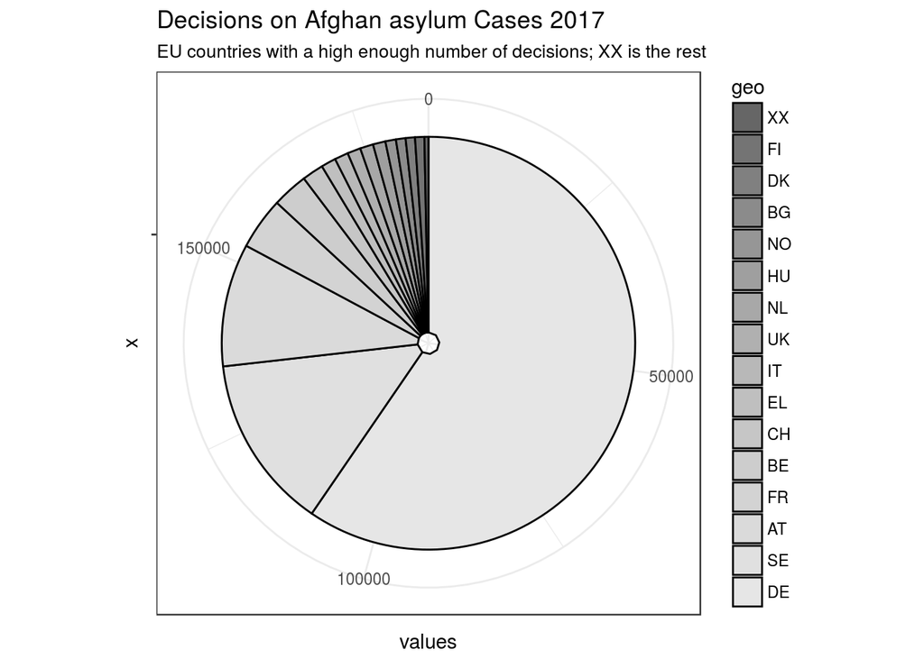

```r
library(ggplot2)
# some technical workarounds for adding the row with the others (XX),
# and for sorting
major_geo_total$geo <- as.character(major_geo_total$geo)
all_geo_total <- rbind(major_geo_total, c("XX",dec_others_total))
all_geo_total$values <- as.numeric(all_geo_total$values)
all_geo_total$geo <- factor(all_geo_total$geo, levels = arrange(all_geo_total, values)$geo)

geo_dec_pie <- ggplot(all_geo_total, aes(x="", y=values, fill=geo)) + geom_col(colour = "black") + coord_polar("y", start=0) + scale_fill_grey(start = 0.4, end = 0.9) + ggtitle ("Decisions on Afghan asylum Cases 2017", subtitle = "EU countries with a high enough number of decisions; XX is the rest")
geo_dec_pie + theme_bw()
```

```r
major_geo_total
```

```
## # A tibble: 15 x 2
##      geo values
##    <chr>  <dbl>
##  1    DE 109732
##  2    SE  25155
##  3    AT  17730
##  4    FR   7516
##  5    BE   5160
##  6    CH   3094
##  7    EL   2134
##  8    IT   1972
##  9    UK   1909
## 10    NL   1894
## 11    HU   1800
## 12    NO   1518
## 13    BG   1388
## 14    DK   1349
## 15    FI   1334
```

Germany had by far the most decisions on Afghanistan in 2017. It is also the most populous country. How does it’s share of decisions compare to it’s share of the population?

For this, we need the eurostat data set `demo_pjan`:

```
 demo_pjan <- get_eurostat(demo_pjan)
 saveRDS(demo_pjan, file = "/tmp/demo_pjan_20180825.rds")
```

```r
demo_pjan <- readRDS(file="/tmp/demo_pjan_20180825.rds")
compare_dec=filter(migr_asydcfsta, time == "2017-01-01", decision == "TOTAL", sex == "T", age == "TOTAL", citizen == "AF", geo != "EU28", geo != "TOTAL") %>% select(geo, values) %>% mutate( stat = "dec")
compare_dec <- droplevels(compare_dec)
compare_pop <- demo_pjan %>% filter(age == "TOTAL" & sex == "T" & time == "2017-01-01" & geo %in% levels(compare_dec$geo)) %>% select(geo, values) %>% mutate( stat = "pop")
compare_pop <- droplevels(compare_pop)
# divide population by 1000, otherwise decisions won't be visible
compare_pop <- mutate(compare_pop, values = values / 1000)
compare_dec_pop <- rbind(compare_dec, compare_pop)
```

Now, the histogram - only for EU countries with a population over 8 mio :

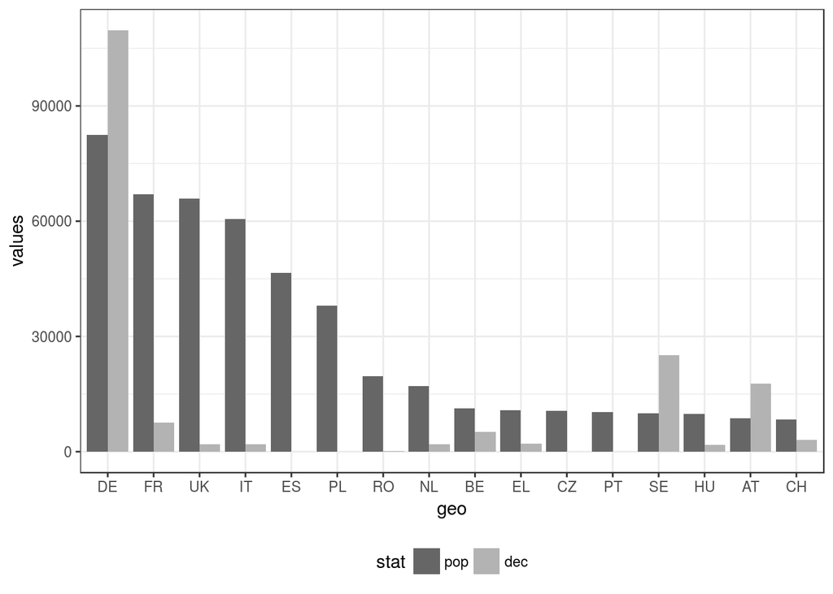

```r
drop_countries_comp <- filter(compare_pop, values < 8000 & stat == "pop") %>% select(geo)
# population first, decisions second
compare_dec_pop$stat <- factor(compare_dec_pop$stat, levels=c("pop","dec"))
# sort by pop
compare_dec_pop$geo <- factor(compare_dec_pop$geo, levels = arrange(filter(compare_dec_pop, stat == "pop"), desc(values))$geo)

bar_compare_dec_pop <- ggplot(filter(compare_dec_pop, !geo %in% unlist(drop_countries_comp)),  aes(x=geo, y=values, fill=stat)) + geom_bar(stat="identity", position="dodge") + theme_bw() + theme(legend.position="bottom") + scale_fill_grey(start = 0.4, end = 0.7)

bar_compare_dec_pop + theme_bw() + theme(legend.position="bottom")
```

## The Decisions: GENCONV + HUMSTAT + SUB_PROT + TEMP_PROT + REJECTED = TOTAL_POS + REJECTED = TOTAL

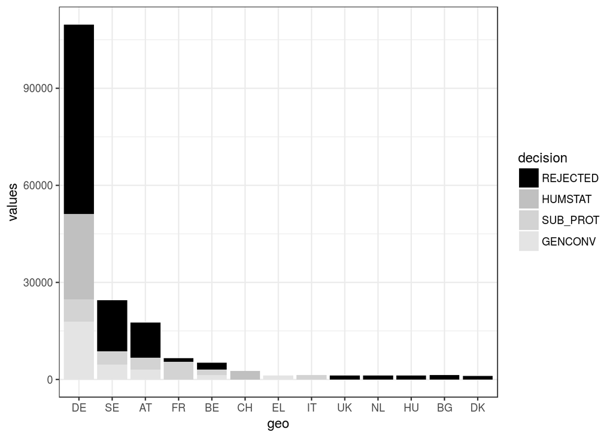

```r
major_geo <-filter(migr_asydcfsta, values > cutoff, time >= "2017-01-01", sex == "T", age == "TOTAL", citizen == "AF", geo != "EU28", geo != "TOTAL") %>%
  select(geo,decision,values)
major_geo$geo <- factor(major_geo$geo, levels = arrange(filter(major_geo, decision == "TOTAL"), desc(values))$geo)
# bring decisions into correct order
major_geo$decision <- factor(major_geo$decision, levels=c("REJECTED","TEMP_PROT","HUMSTAT","SUB_PROT","GENCONV","TOTAL_POS","TOTAL"))
# define grey palette
dec_palette_grey=c("#000000","#C0C0C0","#D3D3D3","#E4E4E4","#E8E8E8","#C8C8C8","#808080")

dec_bar <- ggplot(filter(major_geo, decision != "TOTAL" & decision != "TOTAL_POS")) + geom_col(aes(x=geo, y=values, fill=decision))
dec_bar +  scale_fill_manual(values = dec_palette_grey) + theme_bw()
```

looking at the percentages:

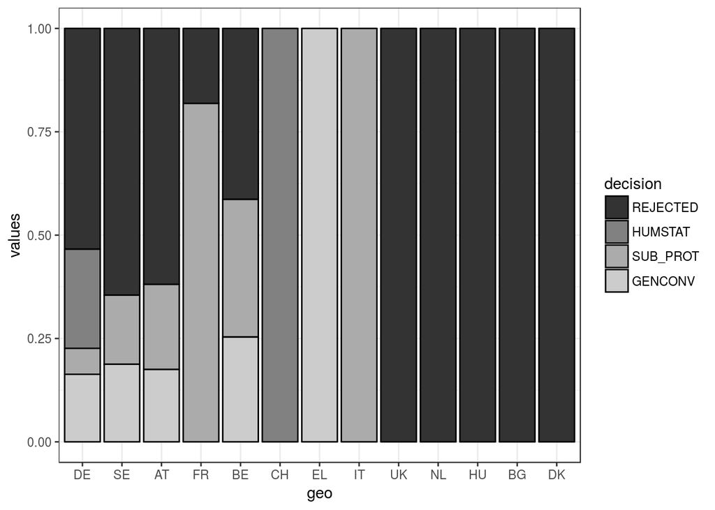

```r
dec_bar_fill <- ggplot(filter(major_geo, decision != "TOTAL" & decision != "TOTAL_POS")) + geom_col(aes(x=geo, y=values, fill=decision), colour="black", position="fill") + scale_fill_grey() + theme_bw()
dec_bar_fill
```

Analysis:

- DE takes care to keep POS below 50% (Bleibeperspektive)
- SE more negativ than expected
- AT no surprise
- FR, BE more positive real surprise: The “small countries” - remember it’s still over 1000 decisions:
- CH, EL IT let all stay
- UK, NL, HU, BG, DK refuse all Does this look like a proper asylum procedure? Like “it doesn’t matter where in the EU you apply for asylum”?

Next questions: * Is the picture (number and result of decisions) similar for SY? Eritrea? TOTAL? * Deportations? We barely have numbers from DE …